# R Notebook

```r
plot(z, sapply(z,densite), type="o",
     ylim=range(c(y,interpolLagrange(40, a_test, b_test, n_eval_test, 'equi', densite))),
     col = 'black')
grid()
```

```r
title(main = paste("Lagrange interpolation with 88 chebyshev nodes"))
lines(z, interpolLagrange(87, a_test, b_test, n_eval_test, 'cheby', densite), col = "red")
```

[figure not shown]

```r
legend('topright', legend=c('function',
                            'interpolation of degree 87'),
                            col = c('black', 'red'), lwd=3)
```

3.1.3.

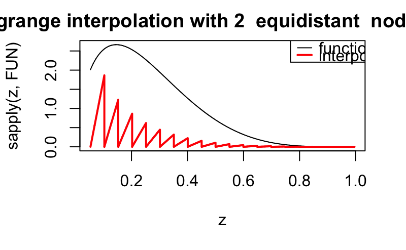

```r
dividif=function(x,y){
##  Newton's Divided differences
    n = length(x) - 1 ## degree of the Lagrange polynomial
    d  = y
    if(n==0){
      d = d/x
    } else {
    for (j in 2:(n+1) ) {d[j : (n+1) ] = (d[j : (n+1)] - d[(j-1):n])/(x[j:(n+1)] - x[1:(n+2-j)])}
      }
    return(d)
}
hornerNewton = function(a,x,z){
## Horner's method: Evaluates a polynom P at points z, given ## nodes x and the coefficients a of P in Newton's basis
##
## @param a : vector: the coefficients of the polynomial in ## Newton's basis
## @param x : the interpolation nodes.
## @param z : vector of points where the polynom needs to be ## evaluated.
## @return : a vector of same size as z: the value of the
## polynomial at points z.
##
n = length(x)
f = a[n]*rep(1,length(z))
if(n==0){stop('at least one interpolating point is needed')}
if(n==1){
  f = f*(z-x[1])
}
if(n >= 2){
       for( i in 1:(n-1)){
           f = f * (z-x[n-i]) + a[n-i]
} }
return(f) }
piecewiseInterpol=function(n,nInt,a,b,neval, nodes = 'equi', FUN, Plot) {
    ## @param n : the degree of the interpolating polynomial on each
    ## subinterval
    ## @param nInt :  the number of sub-intervals
    ## @param a, b : endpoints of the interval
    ## @param neval : the number of points on the interpolating grid (on
    ## each subinterval)
    ## @param nodes : string, either "equi" (default) for equidistant
    ## Lagrange interpolation (on each subinterval) or "cheby" for
    ## chebyshev nodes.
    ## @param FUN the function to be interpolated
    ## @param Plot : logical. Should the result be plotted ?
    ## @return : a matrix with 2 rows and neval * nInt -neval + 1:
    ## values of the interpolated funtion on a regular grid (first row)
    ## and the corresponding abscissas (second row).
    intEndPoints = seq(a,b,length.out = nInt+1)
    f = c()
    z = c()
    for (m in 1:nInt){
        A = intEndPoints[m]; B = intEndPoints[m+1]

        fm = interpolLagrange(n, A, B, neval, nodes, FUN)
        zm = seq(A,B,length.out=length(fm))

            if( m >= 2){
                zm = zm[2:length(fm)];
                fm = fm[2:length(fm)];
        z = c(z,zm);
        f = c(f,fm);
            }
    }
    if (Plot == 0) {
    return(f)
    } else {
        if (nodes == "equi") {methodName = " equidistant "}
        else  {methodName = " Chebyshev "}


        plot(z, sapply(z,FUN),type="l");
        title(main = paste("Piecewise Lagrange interpolation with",
                           toString(n+1), methodName, "nodes on",
                           toString(nInt), "Intervals", sep=" "));
        lines(z,f, col='red', lwd=2);
        legend('topright', legend = c('function','interpolation'),
               lwd=c(1,2), col=c('black','red'));
    }}
# Affichage avec n=1
piecewiseInterpol(1, 20, a_test, b_test, 1000, 'equi', densite, TRUE)
```

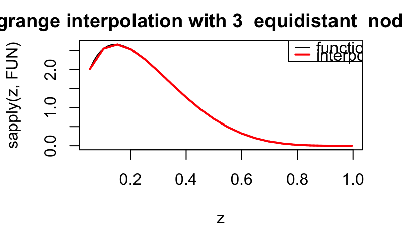

```r
# Affichage avec n=2
piecewiseInterpol(2, 20, a_test, b_test, 1000, 'equi', densite, TRUE)
```

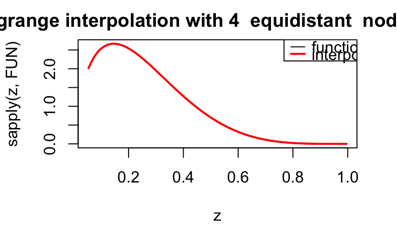

```r
# Affichage avec n = 3
piecewiseInterpol(3, 20, a_test, b_test, 1000, 'equi', densite, TRUE)
```

3.1.4.

1. : M sous-intervalles avec une interpollation de degré 3 correspondent à $3M +1$ points. Mais en raison des (M-1) points communs à deux intervalles cela donne degré 3M avec la méthode “simple”. ($4*(M-1)=3.M$)
2. : L’interpolation par morceau renvoie un vecteur de taille $(neval -1)*nInt+1$, puisque $nInt=M$ si $neval=floor( (2^{10} -1)/M) +1$ on obtient alors un vecteur de taille $M*floor( (2^{10} -1)/M) +1$ d’une différence d’au plus $M-1$ par rapport au $neval=2^{10}$ de la méthode simple.
3. :

```r
densite  = function(x) {
    return(dbeta(x, 1.7, 5.1))
  }
erreur = function(f,FUN){
  z = seq(0,1,length.out = 1000)
  y = FUN(z)
  erreur = 0
  for (k in(length(z))){
    erreur = c(erreur, abs(y[k]-f[k]))
  }
  return (max(erreur))
}
erreurSimple = erreur(interpolLagrange(3+1, a_test, b_test, 2^10, 'equi', densite), densite)
erreurParMorceau = erreur(piecewiseInterpol(3, 20, a_test, b_test, floor((2^10 -1)/1)+1, 'equi', densite, FALSE), densite)
for (M in (2:20)){
  erreurSimple = c(erreurSimple, erreur(interpolLagrange(3*M+1, a_test, b_test, 2^10, 'equi', densite), densite))
  erreurParMorceau = c(erreurParMorceau, erreur(piecewiseInterpol(3, 20, a_test, b_test, floor((2^10 -1)/M)+1, 'equi', densite, FALSE), densite))
}
```

```r
M = c(1,2,3,4,5,6,7,8,9,10,11,12,13,14,15,16,17,18,19,20)
plot(M,erreurParMorceau, type = 'o', col = 'red', ylab = 'Erreur')
lines(M,erreurSimple, type = 'o', col = 'blue')
```

```r
title(main = "Approximation de la norme infinie de l'erreur pour M variant de 1 à 20")
legend('topright', legend = c('methode par morceau','méthode simple'),
               lwd=3, col=c('red','blue'))
```

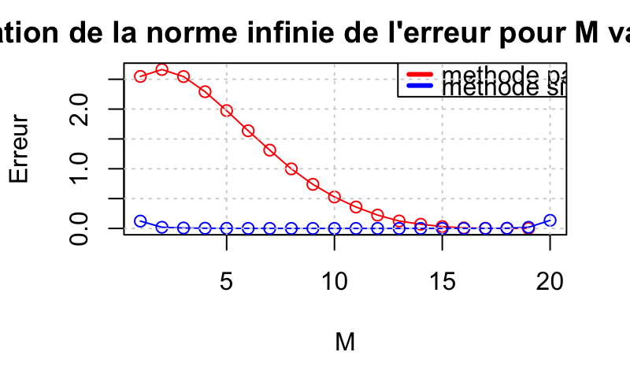

```r
grid()
```

```r
plot(M, erreurSimple, type = 'o', col = 'red', ylab = 'Erreur')
lines(M, erreurParMorceau, type = 'o', col = 'blue')
```

```r
title(main = "Approximation de la norme infinie de l'erreur pour M variant de 1 à 20")
legend('topright', legend = c('methode simple','méthode par morceau'),
               lwd=3, col=c('red','blue'))
```

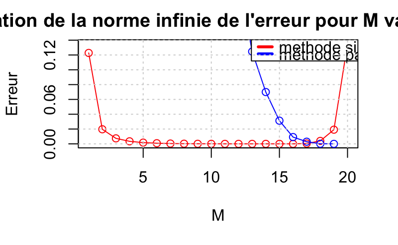

```r
grid()
```

Ainsi, on remarque que la méthode simple est préférable à la méthode par morceau pour $M < 18.$

*3.2. Interpolation à partir de l’histogramme*

*3.2.5.*

**Question 1**

```r
load("/Users/Raph/Desktop/Mini-projet MACS/hist1.rda")
source("~/Desktop/Mini-projet MACS/ini_functions.R")
histog <- hist1
funHisto = function(x){ #On transforme hist_value en une fonction de x afin de pouvoir réutiliser le code précédent.
  return(hist_value(histog,x))
}
space_int <- 2^(-8)
  n_eval_test = 1000
  a_test = 2^(-8)
  b_test = 1 - a_test
  z = seq(a_test,b_test,length.out=n_eval_test)
  y = sapply(z,funHisto)

ref = interpolLagrange(3, a_test, b_test, n_eval_test, 'equi', funHisto)
plot(z, sapply(z,funHisto), type="l",
     ylim=range(c(sapply(z,funHisto),ref)),col = 'black')
grid()
```

```r
title(main = paste("Lagrange interpolation with 4 to 11 equidistant nodes from histogram"))
lines(z, ref, col = "green")
```

```r
lines(z, interpolLagrange(4, a_test, b_test, n_eval_test, 'equi', funHisto), col = "yellow")
lines(z, interpolLagrange(6, a_test, b_test, n_eval_test, 'equi', funHisto), col = "purple")
```

```r
lines(z, interpolLagrange(8, a_test, b_test, n_eval_test, 'equi', funHisto), col = "blue")
lines(z, interpolLagrange(10, a_test, b_test, n_eval_test, 'equi', funHisto), col = "red")
```

[figure not shown]

```r
legend('topright',
       legend=c('function','interpolation of degree 3',
        'interpolation of degree 4', 'interpolation of degree 6',
       'interpolation of degree 8', 'interpolation of degree 10'),
       col = c('black','green', 'yellow', 'purple', 'blue', 'red'), lwd=3)
```

```r
plot(z, sapply(z,funHisto), type="l",
     ylim=range(c(y,interpolLagrange(20, a_test, b_test, n_eval_test, 'equi', funHisto))),
     col = 'black')
grid()
```

```r
title(main = paste("Lagrange interpolation with 21 to 31 equidistant nodes from histogram"))
lines(z, interpolLagrange(20, a_test, b_test, n_eval_test, 'equi', funHisto), col = "red")
```